# Project-1-Schmittj21

```r
library(tidyverse)
library(dplyr)
library(kableExtra)
library(lubridate)
library(knitr)
library(rsample)
library(recipes)
library(GGally)
bike_data <- read.csv("data/bike_share_day.csv")
```

```r
str(bike_data)
```

```
## 'data.frame':    731 obs. of  16 variables:
##  $ instant   : int  1 2 3 4 5 6 7 8 9 10 ...
##  $ dteday    : chr  "1/1/11" "1/2/11" "1/3/11" "1/4/11" ...
##  $ season    : int  1 1 1 1 1 1 1 1 1 1 ...
##  $ yr        : int  0 0 0 0 0 0 0 0 0 0 ...
##  $ mnth      : int  1 1 1 1 1 1 1 1 1 1 ...
##  $ holiday   : int  0 0 0 0 0 0 0 0 0 0 ...
##  $ weekday   : int  6 0 1 2 3 4 5 6 0 1 ...
##  $ workingday: int  0 0 1 1 1 1 1 0 0 1 ...
##  $ weathersit: int  2 2 1 1 1 1 2 2 1 1 ...
##  $ temp      : num  0.344 0.363 0.196 0.2 0.227 ...
##  $ atemp     : num  0.364 0.354 0.189 0.212 0.229 ...
##  $ hum       : num  0.806 0.696 0.437 0.59 0.437 ...
##  $ windspeed : num  0.16 0.249 0.248 0.16 0.187 ...
##  $ casual    : int  331 131 120 108 82 88 148 68 54 41 ...
##  $ registered: int  654 670 1229 1454 1518 1518 1362 891 768 1280 ...
##  $ cnt       : int  985 801 1349 1562 1600 1606 1510 959 822 1321 ...
```

```r
view(bike_data)
```

# Question 1

```r
bike_data <- bike_data %>%
  rename( year= "yr",
          date_r = "dteday",
          month= "mnth",
          weathercd = "weathersit",
          actual_temp = "temp",
          real_feel = "atemp",
          humidity = "hum",
          casual_users = "casual",
          registered_users = "registered",
          total_cnt = "cnt")
```

```r
bike_data %>%
  head(50) %>%
  kable %>%
  kable_styling()
```

| instant | date_r | season | year | month | holiday | weekday | workingday | weathercd | actual_temp | real_feel | humidity | windspeed | casual_users | registered_users | total_cnt |
| --- | --- | --- | --- | --- | --- | --- | --- | --- | --- | --- | --- | --- | --- | --- | --- |
| 1 | 1/1/11 | 1 | 0 | 1 | 0 | 6 | 0 | 2 | 0.3441670 | 0.3636250 | 0.805833 | 0.1604460 | 331 | 654 | 985 |
| 2 | 1/2/11 | 1 | 0 | 1 | 0 | 0 | 0 | 2 | 0.3634780 | 0.3537390 | 0.696087 | 0.2485390 | 131 | 670 | 801 |
| 3 | 1/3/11 | 1 | 0 | 1 | 0 | 1 | 1 | 1 | 0.1963640 | 0.1894050 | 0.437273 | 0.2483090 | 120 | 1229 | 1349 |
| 4 | 1/4/11 | 1 | 0 | 1 | 0 | 2 | 1 | 1 | 0.2000000 | 0.2121220 | 0.590435 | 0.1602960 | 108 | 1454 | 1562 |
| 5 | 1/5/11 | 1 | 0 | 1 | 0 | 3 | 1 | 1 | 0.2269570 | 0.2292700 | 0.436957 | 0.1869000 | 82 | 1518 | 1600 |
| 6 | 1/6/11 | 1 | 0 | 1 | 0 | 4 | 1 | 1 | 0.2043480 | 0.2332090 | 0.518261 | 0.0895652 | 88 | 1518 | 1606 |
| 7 | 1/7/11 | 1 | 0 | 1 | 0 | 5 | 1 | 2 | 0.1965220 | 0.2088390 | 0.498696 | 0.1687260 | 148 | 1362 | 1510 |
| 8 | 1/8/11 | 1 | 0 | 1 | 0 | 6 | 0 | 2 | 0.1650000 | 0.1622540 | 0.535833 | 0.2668040 | 68 | 891 | 959 |
| 9 | 1/9/11 | 1 | 0 | 1 | 0 | 0 | 0 | 1 | 0.1383330 | 0.1161750 | 0.434167 | 0.3619500 | 54 | 768 | 822 |
| 10 | 1/10/11 | 1 | 0 | 1 | 0 | 1 | 1 | 1 | 0.1508330 | 0.1508880 | 0.482917 | 0.2232670 | 41 | 1280 | 1321 |
| 11 | 1/11/11 | 1 | 0 | 1 | 0 | 2 | 1 | 2 | 0.1690910 | 0.1914640 | 0.686364 | 0.1221320 | 43 | 1220 | 1263 |
| 12 | 1/12/11 | 1 | 0 | 1 | 0 | 3 | 1 | 1 | 0.1727270 | 0.1604730 | 0.599545 | 0.3046270 | 25 | 1137 | 1162 |
| 13 | 1/13/11 | 1 | 0 | 1 | 0 | 4 | 1 | 1 | 0.1650000 | 0.1508830 | 0.470417 | 0.3010000 | 38 | 1368 | 1406 |
| 14 | 1/14/11 | 1 | 0 | 1 | 0 | 5 | 1 | 1 | 0.1608700 | 0.1884130 | 0.537826 | 0.1265480 | 54 | 1367 | 1421 |
| 15 | 1/15/11 | 1 | 0 | 1 | 0 | 6 | 0 | 2 | 0.2333330 | 0.2481120 | 0.498750 | 0.1579630 | 222 | 1026 | 1248 |
| 16 | 1/16/11 | 1 | 0 | 1 | 0 | 0 | 0 | 1 | 0.2316670 | 0.2342170 | 0.483750 | 0.1884330 | 251 | 953 | 1204 |
| 17 | 1/17/11 | 1 | 0 | 1 | 1 | 1 | 0 | 2 | 0.1758330 | 0.1767710 | 0.537500 | 0.1940170 | 117 | 883 | 1000 |
| 18 | 1/18/11 | 1 | 0 | 1 | 0 | 2 | 1 | 2 | 0.2166670 | 0.2323330 | 0.861667 | 0.1467750 | 9 | 674 | 683 |
| 19 | 1/19/11 | 1 | 0 | 1 | 0 | 3 | 1 | 2 | 0.2921740 | 0.2984220 | 0.741739 | 0.2083170 | 78 | 1572 | 1650 |
| 20 | 1/20/11 | 1 | 0 | 1 | 0 | 4 | 1 | 2 | 0.2616670 | 0.2550500 | 0.538333 | 0.1959040 | 83 | 1844 | 1927 |
| 21 | 1/21/11 | 1 | 0 | 1 | 0 | 5 | 1 | 1 | 0.1775000 | 0.1578330 | 0.457083 | 0.3532420 | 75 | 1468 | 1543 |
| 22 | 1/22/11 | 1 | 0 | 1 | 0 | 6 | 0 | 1 | 0.0591304 | 0.0790696 | 0.400000 | 0.1719700 | 93 | 888 | 981 |
| 23 | 1/23/11 | 1 | 0 | 1 | 0 | 0 | 0 | 1 | 0.0965217 | 0.0988391 | 0.436522 | 0.2466000 | 150 | 836 | 986 |
| 24 | 1/24/11 | 1 | 0 | 1 | 0 | 1 | 1 | 1 | 0.0973913 | 0.1179300 | 0.491739 | 0.1583300 | 86 | 1330 | 1416 |
| 25 | 1/25/11 | 1 | 0 | 1 | 0 | 2 | 1 | 2 | 0.2234780 | 0.2345260 | 0.616957 | 0.1297960 | 186 | 1799 | 1985 |
| 26 | 1/26/11 | 1 | 0 | 1 | 0 | 3 | 1 | 3 | 0.2175000 | 0.2036000 | 0.862500 | 0.2938500 | 34 | 472 | 506 |
| 27 | 1/27/11 | 1 | 0 | 1 | 0 | 4 | 1 | 1 | 0.1950000 | 0.2197000 | 0.687500 | 0.1138370 | 15 | 416 | 431 |
| 28 | 1/28/11 | 1 | 0 | 1 | 0 | 5 | 1 | 2 | 0.2034780 | 0.2233170 | 0.793043 | 0.1233000 | 38 | 1129 | 1167 |
| 29 | 1/29/11 | 1 | 0 | 1 | 0 | 6 | 0 | 1 | 0.1965220 | 0.2121260 | 0.651739 | 0.1453650 | 123 | 975 | 1098 |
| 30 | 1/30/11 | 1 | 0 | 1 | 0 | 0 | 0 | 1 | 0.2165220 | 0.2503220 | 0.722174 | 0.0739826 | 140 | 956 | 1096 |
| 31 | 1/31/11 | 1 | 0 | 1 | 0 | 1 | 1 | 2 | 0.1808330 | 0.1862500 | 0.603750 | 0.1871920 | 42 | 1459 | 1501 |
| 32 | 2/1/11 | 1 | 0 | 2 | 0 | 2 | 1 | 2 | 0.1921740 | 0.2345300 | 0.829565 | 0.0532130 | 47 | 1313 | 1360 |
| 33 | 2/2/11 | 1 | 0 | 2 | 0 | 3 | 1 | 2 | 0.2600000 | 0.2544170 | 0.775417 | 0.2643080 | 72 | 1454 | 1526 |
| 34 | 2/3/11 | 1 | 0 | 2 | 0 | 4 | 1 | 1 | 0.1869570 | 0.1778780 | 0.437826 | 0.2777520 | 61 | 1489 | 1550 |
| 35 | 2/4/11 | 1 | 0 | 2 | 0 | 5 | 1 | 2 | 0.2113040 | 0.2285870 | 0.585217 | 0.1278390 | 88 | 1620 | 1708 |
| 36 | 2/5/11 | 1 | 0 | 2 | 0 | 6 | 0 | 2 | 0.2333330 | 0.2430580 | 0.929167 | 0.1610790 | 100 | 905 | 1005 |
| 37 | 2/6/11 | 1 | 0 | 2 | 0 | 0 | 0 | 1 | 0.2858330 | 0.2916710 | 0.568333 | 0.1418000 | 354 | 1269 | 1623 |
| 38 | 2/7/11 | 1 | 0 | 2 | 0 | 1 | 1 | 1 | 0.2716670 | 0.3036580 | 0.738333 | 0.0454083 | 120 | 1592 | 1712 |
| 39 | 2/8/11 | 1 | 0 | 2 | 0 | 2 | 1 | 1 | 0.2208330 | 0.1982460 | 0.537917 | 0.3619500 | 64 | 1466 | 1530 |
| 40 | 2/9/11 | 1 | 0 | 2 | 0 | 3 | 1 | 2 | 0.1347830 | 0.1442830 | 0.494783 | 0.1888390 | 53 | 1552 | 1605 |
| 41 | 2/10/11 | 1 | 0 | 2 | 0 | 4 | 1 | 1 | 0.1443480 | 0.1495480 | 0.437391 | 0.2219350 | 47 | 1491 | 1538 |
| 42 | 2/11/11 | 1 | 0 | 2 | 0 | 5 | 1 | 1 | 0.1890910 | 0.2135090 | 0.506364 | 0.1085500 | 149 | 1597 | 1746 |
| 43 | 2/12/11 | 1 | 0 | 2 | 0 | 6 | 0 | 1 | 0.2225000 | 0.2329540 | 0.544167 | 0.2033670 | 288 | 1184 | 1472 |
| 44 | 2/13/11 | 1 | 0 | 2 | 0 | 0 | 0 | 1 | 0.3165220 | 0.3241130 | 0.457391 | 0.2608830 | 397 | 1192 | 1589 |
| 45 | 2/14/11 | 1 | 0 | 2 | 0 | 1 | 1 | 1 | 0.4150000 | 0.3983500 | 0.375833 | 0.4179080 | 208 | 1705 | 1913 |
| 46 | 2/15/11 | 1 | 0 | 2 | 0 | 2 | 1 | 1 | 0.2660870 | 0.2542740 | 0.314348 | 0.2913740 | 140 | 1675 | 1815 |
| 47 | 2/16/11 | 1 | 0 | 2 | 0 | 3 | 1 | 1 | 0.3182610 | 0.3162000 | 0.423478 | 0.2517910 | 218 | 1897 | 2115 |
| 48 | 2/17/11 | 1 | 0 | 2 | 0 | 4 | 1 | 1 | 0.4358330 | 0.4286580 | 0.505000 | 0.2301040 | 259 | 2216 | 2475 |
| 49 | 2/18/11 | 1 | 0 | 2 | 0 | 5 | 1 | 1 | 0.5216670 | 0.5119830 | 0.516667 | 0.2649250 | 579 | 2348 | 2927 |
| 50 | 2/19/11 | 1 | 0 | 2 | 0 | 6 | 0 | 1 | 0.3991670 | 0.3914040 | 0.187917 | 0.5074630 | 532 | 1103 | 1635 |

I chose to rename the a multitude of functions for legibility and convienance sake. I renamed yr to year to complete the word as it is very short without the breevation and can prevent confusion. The same resonsing was behind my decision to rename mnth to month. the name weathersit did not make sense so i renamed the column to weathercd to abrreviate weather code as the variable indicated the weather. I renamed temp to actual_temp, atemp to real_feel, hum to humidity, casual to casual_users, registered to registered_users and cnt to total_cnt to more accurately reflect what each columns aimed to measure. All of these renames make the data frame more understandable and userfriendly.

```r
bike_data %>%
  filter(is.na(1:731)) %>%
  count()
```

```
##   n
## 1 0
```

I filter all the data that shows a “n/a” using a filter function, asking it to look at all observations (1-731). After I count all the records that included “n/a” which totaled zero, meaning there was no missing data.

# Question 2a

```r
bike_data <- bike_data %>%
mutate(season = factor(season, labels = c("Winter", "Spring","Summer", "Fall"))) %>%
mutate(season = factor(season, levels = c( "Spring", "Summer","Fall", "Winter")))
```

In this example, I first label the different factors and first turn season into a factor style column by directly altering bike_data data frame using the mutate function. Then, I re-level specific labels in the required order by specifying them in that order after using labels in the factor function.

# Question 2b

```r
bike_data <- bike_data %>%
mutate(workingday = factor(workingday, labels = c("no","yes"))) %>%
mutate(holiday = factor(holiday, labels = c("no","yes")))
```

In this example, we directly alter (factor) the bike_data data frame to turn numbers into corresponding words. I first specify that bike data data frame will be altered by using an assignment operator “<-” and referencing bike_data so that following function knows where to gather the input material, using a pipe to pass this to the mutate function. The mutate function allows the factor function to alter workingday, specifying the necesary labels using the labels function. I do the same process for Holiday. Note their is no need to re-level because they are in alphabetical order.

# Question 2c

```r
bike_data <- bike_data %>%
mutate(year = factor(year, labels = c("2011", "2012")))
```

In this problem, I directly alter the bike_data data frame using the mutate function. I first specify that I want to turn the year column into a factor style and then specify the labels using the labels specifier within the factor function.

# Question 2d

```r
bike_data <- bike_data %>%
mutate(weathercd = factor(weathercd, labels = c("clear","mist", "light_precipitation")))
```

Again, I directly alter the bike_data dataframe using the mutate function and factor function to (1) change the columnn type of weathercd to a factor style and (2) specify the labels of each number using the label specifier within the factor function. Also there are only three binary labels to attach labels to so we take out the fourth label as it is impossible to attach it to not existent binary.

# Question 3

```r
bike_data <- bike_data %>%
mutate(raw_temp = actual_temp*41) %>%
mutate(feeling_temp = real_feel*50) %>%
mutate(humid = humidity*100) %>%
mutate(wind_speed = windspeed*67)
```

In this problem, i directly alter the bike_data dataframe using a series of mutate functions. The goal of each being to negate the previous division done to each column and restore the values to their original amounts. I use pipes between each line to transfer the data between them and indicate multiple mutates should have affect on the aforementioned dataframe, except the last line because their is no following line that should have an affect.

# Question 4

```r
bike_data %>%
  mutate(total_users = casual_users + registered_users) %>%
  select(total_cnt, total_users)%>%
  head(10)
```

```
##    total_cnt total_users
## 1        985         985
## 2        801         801
## 3       1349        1349
## 4       1562        1562
## 5       1600        1600
## 6       1606        1606
## 7       1510        1510
## 8        959         959
## 9        822         822
## 10      1321        1321
```

# Question 5

```r
bike_data <- bike_data %>%
mutate(date_r = mdy(date_r))
```

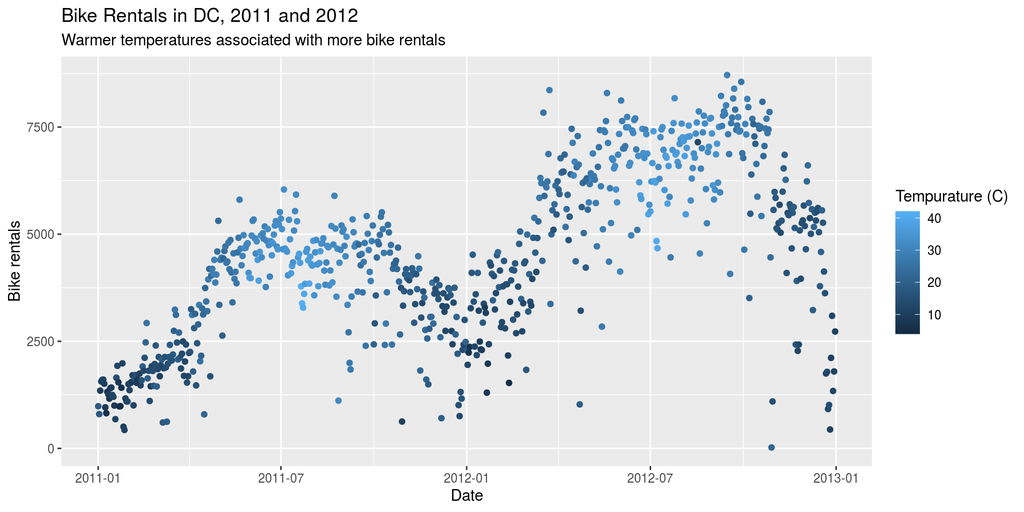

```r
bike_data %>%
ggplot(aes(x = date_r, y = total_cnt)) +
geom_point(aes(color = feeling_temp)) +
labs(title = "Bike Rentals in DC, 2011 and 2012", x = "Date", y = "Bike rentals", subtitle = "Warmer temperatures associated with more bike rentals", color = "Tempurature (C)")
```

This question asks us to recreate a scatterplot. after referencing bike_data dataframe and using a pipe, i use ggplot to add a higher level of customizability than other functions such as plot. After, I use the aes function, within the ggplot, to specify the x and y axis, I include a + to continue the function to include geom_point which I use aes again to specify that temperature should be indicated by color. I use a + again to pass the function on to specify the “labs” which i use to specifically input the title, axis labels, the subtitle, and legend title.

# Question 6

```r
bike_data <- bike_data %>%
mutate(month = factor(month, labels = c("January","February", "March","April","May","June", "July","August","September","October", "November","December")))
```

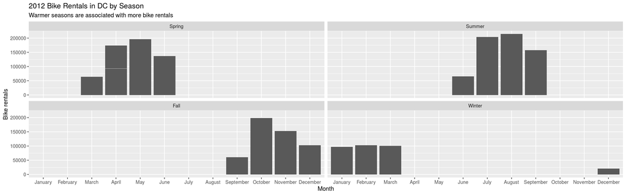

```r
bike_data %>%
filter(year == 2012) %>%
ggplot(aes(x = month, y = total_cnt)) +
geom_col() +
facet_wrap(~season)+
labs(title = "2012 Bike Rentals in DC by Season ", x = "Month", y = "Bike rentals", subtitle = "Warmer seasons are associated with more bike rentals")
```

# Question 7

```r
set.seed(2021)
bike_data_split <- bike_data %>%
initial_split(prop = .75)

training_bike <- training(bike_data_split)
validation_bike <- testing(bike_data_split)

training_bike %>%
  head(10)
```

```
##    instant     date_r season year   month holiday weekday workingday weathercd
## 1        1 2011-01-01 Winter 2011 January      no       6         no      mist
## 2        2 2011-01-02 Winter 2011 January      no       0         no      mist
## 3        3 2011-01-03 Winter 2011 January      no       1        yes     clear
## 4        4 2011-01-04 Winter 2011 January      no       2        yes     clear
## 5        5 2011-01-05 Winter 2011 January      no       3        yes     clear
## 6        6 2011-01-06 Winter 2011 January      no       4        yes     clear
## 8        8 2011-01-08 Winter 2011 January      no       6         no      mist
## 9        9 2011-01-09 Winter 2011 January      no       0         no     clear
## 10      10 2011-01-10 Winter 2011 January      no       1        yes     clear
## 11      11 2011-01-11 Winter 2011 January      no       2        yes      mist
##    actual_temp real_feel humidity windspeed casual_users registered_users
## 1     0.344167  0.363625 0.805833 0.1604460          331              654
## 2     0.363478  0.353739 0.696087 0.2485390          131              670
## 3     0.196364  0.189405 0.437273 0.2483090          120             1229
```

[output cut: 18 more lines]

```r
validation_bike %>%
  head(10)
```

```
##    instant     date_r season year    month holiday weekday workingday weathercd
## 7        7 2011-01-07 Winter 2011  January      no       5        yes      mist
## 13      13 2011-01-13 Winter 2011  January      no       4        yes     clear
## 20      20 2011-01-20 Winter 2011  January      no       4        yes      mist
## 27      27 2011-01-27 Winter 2011  January      no       4        yes     clear
## 28      28 2011-01-28 Winter 2011  January      no       5        yes      mist
## 41      41 2011-02-10 Winter 2011 February      no       4        yes     clear
## 43      43 2011-02-12 Winter 2011 February      no       6         no     clear
## 48      48 2011-02-17 Winter 2011 February      no       4        yes     clear
## 49      49 2011-02-18 Winter 2011 February      no       5        yes     clear
## 57      57 2011-02-26 Winter 2011 February      no       6         no     clear
##    actual_temp real_feel humidity windspeed casual_users registered_users
## 7     0.196522  0.208839 0.498696  0.168726          148             1362
## 13    0.165000  0.150883 0.470417  0.301000           38             1368
## 20    0.261667  0.255050 0.538333  0.195904           83             1844
```

[output cut: 18 more lines]

```r
validation_bike %>%
  count(.)
```

```
##     n
## 1 182
```

```r
training_bike %>%
  count(.)
```

```
##     n
## 1 549
```

# Question 8

```r
car_data <- read.csv("data/ToyotaCorolla.csv")
view(car_data)
```

```r
car_data <- car_data %>%
  rename( age= "Age_08_04",
          model = "Model",
          price = "Price",
          doors = "Doors",
          fuel_type = "Fuel_Type",
          quarterly_tax = "Quarterly_Tax",
          weight = "Weight",
          met_color = "Met_Color",
          automatic = "Automatic")
```

```r
car_data <-
select(car_data, -Mfg_Month, -Mfg_Year, -Cylinders, -Gears, -Mfr_Guarantee, -BOVAG_Guarantee, -Guarantee_Period, -ABS, -Airbag_1, -Airbag_2, -Airco, -Automatic_airco, -Boardcomputer, -CD_Player, -Central_Lock, -Powered_Windows, -Power_Steering, -Radio, -Mistlamps, -Sport_Model, -Backseat_Divider, -Metallic_Rim, -Radio_cassette, -Tow_Bar)
```

In this problem, I load the data, rename the columns using the rename function, and remove unnecessary columns using the minus in the dyplr package sign and select function. Afterwards, I view the data to ensure these steps were completed.

# Question 9

```r
view(car_data)
glimpse(car_data)
```

```
## Rows: 1,436
## Columns: 13
## $ Id            <int> 1, 2, 3, 4, 5, 6, 7, 8, 9, 10, 11, 12, 13, 14, 15, 16, …
## $ model         <chr> "TOYOTA Corolla 2.0 D4D HATCHB TERRA 2/3-Doors", "TOYOT…
## $ price         <int> 13500, 13750, 13950, 14950, 13750, 12950, 16900, 18600,…
## $ age           <int> 23, 23, 24, 26, 30, 32, 27, 30, 27, 23, 25, 22, 25, 31,…
## $ KM            <int> 46986, 72937, 41711, 48000, 38500, 61000, 94612, 75889,…
## $ fuel_type     <chr> "Diesel", "Diesel", "Diesel", "Diesel", "Diesel", "Dies…
## $ HP            <int> 90, 90, 90, 90, 90, 90, 90, 90, 192, 69, 192, 192, 192,…
## $ met_color     <int> 1, 1, 1, 0, 0, 0, 1, 1, 0, 0, 0, 0, 0, 1, 1, 0, 1, 1, 0…
## $ automatic     <int> 0, 0, 0, 0, 0, 0, 0, 0, 0, 0, 0, 0, 0, 0, 0, 0, 0, 0, 0…
## $ cc            <int> 2000, 2000, 2000, 2000, 2000, 2000, 2000, 2000, 1800, 1…
## $ doors         <int> 3, 3, 3, 3, 3, 3, 3, 3, 3, 3, 3, 3, 3, 3, 3, 3, 3, 3, 3…
## $ quarterly_tax <int> 210, 210, 210, 210, 210, 210, 210, 210, 100, 185, 100, …
## $ weight        <int> 1165, 1165, 1165, 1165, 1170, 1170, 1245, 1245, 1185, 1…
```

```r
str(car_data)
```

```
## 'data.frame':    1436 obs. of  13 variables:
##  $ Id           : int  1 2 3 4 5 6 7 8 9 10 ...
##  $ model        : chr  "TOYOTA Corolla 2.0 D4D HATCHB TERRA 2/3-Doors" "TOYOTA Corolla 2.0 D4D HATCHB TERRA 2/3-Doors" "?TOYOTA Corolla 2.0 D4D HATCHB TERRA 2/3-Doors" "TOYOTA Corolla 2.0 D4D HATCHB TERRA 2/3-Doors" ...
##  $ price        : int  13500 13750 13950 14950 13750 12950 16900 18600 21500 12950 ...
##  $ age          : int  23 23 24 26 30 32 27 30 27 23 ...
##  $ KM           : int  46986 72937 41711 48000 38500 61000 94612 75889 19700 71138 ...
##  $ fuel_type    : chr  "Diesel" "Diesel" "Diesel" "Diesel" ...
##  $ HP           : int  90 90 90 90 90 90 90 90 192 69 ...
##  $ met_color    : int  1 1 1 0 0 0 1 1 0 0 ...
##  $ automatic    : int  0 0 0 0 0 0 0 0 0 0 ...
##  $ cc           : int  2000 2000 2000 2000 2000 2000 2000 2000 1800 1900 ...
##  $ doors        : int  3 3 3 3 3 3 3 3 3 3 ...
##  $ quarterly_tax: int  210 210 210 210 210 210 210 210 100 185 ...
##  $ weight       : int  1165 1165 1165 1165 1170 1170 1245 1245 1185 1105 ...
```

```r
car_data %>%
filter(is.na(1:1436)) %>%
count()
```

```
##   n
## 1 0
```

In this problem, I am exploring the dataset. I use the view function, glimpse function, and the str (structure) function to look at the dataset in a variety of ways. Secondly, I filter all the data that shows a “n/a” using a filter function, asking it to look at all observations (1-1436), the total being shown by the glimpse function. After I count all the records that included “n/a” which totaled zero, meaning there was no missing data.

# Question 10

```r
car_data <-  car_data %>%
  mutate(model = str_replace(model, "\\?", ""))
view(car_data)
```

For this problem, I use a mutate function to alter the original dataset, a str_replace function to replace a string with something else, nothing in this case, and specify a question mark as the string to be replaced, using two backslashes to help the function read the question mark. After using another view to look at the newly altered data, I quickly used the view to scroll through the data without finding any other variables that need cleaning.

# Question 11

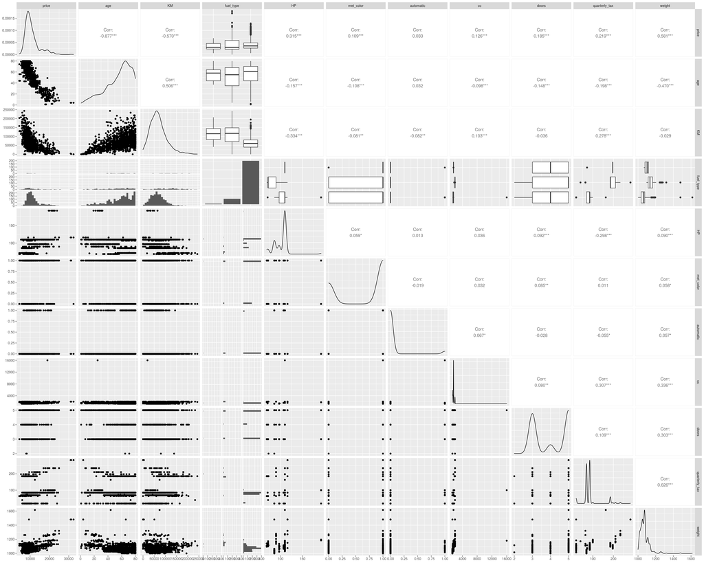

```r
car_data %>%
select(price, age, KM, fuel_type, HP, met_color, automatic, cc, doors, quarterly_tax, weight) %>%
ggpairs()
```

# Question 12

```r
#Turn the Columns into Factors
car_data <- car_data %>%
mutate(met_color = factor(met_color, labels = c("None","Metallic")))

car_data <- car_data %>%
mutate(automatic = factor(automatic, labels = c("None","Automatic")))

car_data <- car_data %>%
mutate(fuel_type = factor(fuel_type))

#Creating the Dummy Variables
car_data <- car_data %>%
  recipe(~.) %>%
  step_dummy(met_color, automatic, fuel_type, preserve = TRUE, one_hot = TRUE) %>%
  prep(training = car_data) %>%
  bake(new_data = car_data)
```

```r
view(car_data)
```

This question asks us to create dummy variables based on 3 variables, met_color, Automatic, fuel_type. Before creating the dummy variables for each of the 3 variable, converted the column style to factor using a factor function within a mutate function so that the orginal data set is altered. Afterwards, I refrence car_data and include a pipe, use the recipe function, the step dummy function, the prep function, and the bake function, using pipes where neccesary. After doing this process for each variable, I use a view function to ensure the results are correct.

# Question 13

```r
#First Split
set.seed(2021)
car_data_split <- car_data %>%
initial_split(prop = .50)

training_car <- training(car_data_split)
validation_car <- testing(car_data_split)

training_car %>%
  glimpse()
```

```
## Rows: 718
## Columns: 20
## $ Id                  <int> 1, 2, 4, 5, 6, 9, 11, 13, 14, 15, 19, 21, 22, 25,…
## $ model               <fct> TOYOTA Corolla 2.0 D4D HATCHB TERRA 2/3-Doors, TO…
## $ price               <int> 13500, 13750, 14950, 13750, 12950, 21500, 20950, …
## $ age                 <int> 23, 23, 26, 30, 32, 27, 25, 25, 31, 32, 24, 30, 2…
## $ KM                  <int> 46986, 72937, 48000, 38500, 61000, 19700, 31461, …
## $ fuel_type           <fct> Diesel, Diesel, Diesel, Diesel, Diesel, Petrol, P…
## $ HP                  <int> 90, 90, 90, 90, 90, 192, 192, 192, 192, 192, 110,…
## $ met_color           <fct> Metallic, Metallic, None, None, None, None, None,…
## $ automatic           <fct> None, None, None, None, None, None, None, None, N…
## $ cc                  <int> 2000, 2000, 2000, 2000, 2000, 1800, 1800, 1800, 1…
## $ doors               <int> 3, 3, 3, 3, 3, 3, 3, 3, 3, 3, 3, 3, 3, 3, 3, 3, 3…
## $ quarterly_tax       <int> 210, 210, 210, 210, 210, 100, 100, 100, 100, 100,…
## $ weight              <int> 1165, 1165, 1165, 1170, 1170, 1185, 1185, 1185, 1…
## $ met_color_None      <dbl> 0, 0, 1, 1, 1, 1, 1, 1, 0, 0, 1, 0, 1, 0, 0, 0, 0…
## $ met_color_Metallic  <dbl> 1, 1, 0, 0, 0, 0, 0, 0, 1, 1, 0, 1, 0, 1, 1, 1, 1…
## $ automatic_None      <dbl> 1, 1, 1, 1, 1, 1, 1, 1, 1, 1, 1, 1, 0, 1, 1, 1, 1…
## $ automatic_Automatic <dbl> 0, 0, 0, 0, 0, 0, 0, 0, 0, 0, 0, 0, 1, 0, 0, 0, 0…
## $ fuel_type_CNG       <dbl> 0, 0, 0, 0, 0, 0, 0, 0, 0, 0, 0, 0, 0, 0, 0, 0, 0…
## $ fuel_type_Diesel    <dbl> 1, 1, 1, 1, 1, 0, 0, 0, 0, 0, 0, 0, 0, 0, 0, 0, 0…
## $ fuel_type_Petrol    <dbl> 0, 0, 0, 0, 0, 1, 1, 1, 1, 1, 1, 1, 1, 1, 1, 1, 1…
```

```r
validation_car %>%
  glimpse()
```

```
## Rows: 718
## Columns: 20
## $ Id                  <int> 3, 7, 8, 10, 12, 16, 17, 18, 20, 23, 24, 27, 28, …
## $ model               <fct> TOYOTA Corolla 2.0 D4D HATCHB TERRA 2/3-Doors, TO…
## $ price               <int> 13950, 16900, 18600, 12950, 19950, 22000, 22750, …
## $ age                 <int> 24, 27, 30, 23, 22, 28, 30, 24, 30, 28, 28, 27, 2…
## $ KM                  <int> 41711, 94612, 75889, 71138, 43610, 18739, 34000, …
## $ fuel_type           <fct> Diesel, Diesel, Diesel, Diesel, Petrol, Petrol, P…
## $ HP                  <int> 90, 90, 90, 69, 192, 192, 192, 110, 110, 110, 110…
## $ met_color           <fct> Metallic, Metallic, Metallic, None, None, None, M…
## $ automatic           <fct> None, None, None, None, None, None, None, None, N…
## $ cc                  <int> 2000, 2000, 2000, 1900, 1800, 1800, 1800, 1600, 1…
## $ doors               <int> 3, 3, 3, 3, 3, 3, 3, 3, 3, 3, 3, 3, 3, 3, 3, 3, 3…
## $ quarterly_tax       <int> 210, 210, 210, 185, 100, 100, 100, 85, 85, 85, 85…
## $ weight              <int> 1165, 1245, 1245, 1105, 1185, 1185, 1185, 1105, 1…
## $ met_color_None      <dbl> 0, 0, 0, 1, 1, 1, 0, 0, 0, 0, 0, 0, 0, 1, 0, 0, 1…
## $ met_color_Metallic  <dbl> 1, 1, 1, 0, 0, 0, 1, 1, 1, 1, 1, 1, 1, 0, 1, 1, 0…
## $ automatic_None      <dbl> 1, 1, 1, 1, 1, 1, 1, 1, 1, 1, 1, 1, 1, 1, 1, 1, 1…
## $ automatic_Automatic <dbl> 0, 0, 0, 0, 0, 0, 0, 0, 0, 0, 0, 0, 0, 0, 0, 0, 0…
## $ fuel_type_CNG       <dbl> 0, 0, 0, 0, 0, 0, 0, 0, 0, 0, 0, 0, 0, 0, 0, 0, 0…
## $ fuel_type_Diesel    <dbl> 1, 1, 1, 1, 0, 0, 0, 0, 0, 0, 0, 0, 0, 0, 0, 0, 0…
## $ fuel_type_Petrol    <dbl> 0, 0, 0, 0, 1, 1, 1, 1, 1, 1, 1, 1, 1, 1, 1, 1, 1…
```

First, I used set.seed to create a consistant random sample. I then create a dataframe called car_data_split using the car_data dataframe and initial_split function set at 50% to partition the data in half. I then create two more dataframes, training_car and validation_car using the car_data_split. I then view the new dataframes using the glimpse function, to display the number of rows and columns, the column names, along with sample data.

```r
#Second Split
set.seed(2021)
car_data_split_2 <- validation_car %>%
initial_split(prop = .60)

validation_car_2 <- training(car_data_split_2)
test_car_2 <- testing(car_data_split_2)

validation_car_2 %>%
  glimpse()
```

```
## Rows: 431
## Columns: 20
## $ Id                  <int> 3, 7, 8, 10, 12, 16, 20, 23, 27, 29, 33, 34, 36, …
## $ model               <fct> TOYOTA Corolla 2.0 D4D HATCHB TERRA 2/3-Doors, TO…
## $ price               <int> 13950, 16900, 18600, 12950, 19950, 22000, 16950, …
## $ age                 <int> 24, 27, 30, 23, 22, 28, 30, 28, 27, 28, 27, 26, 2…
## $ KM                  <int> 41711, 94612, 75889, 71138, 43610, 18739, 64359, …
## $ fuel_type           <fct> Diesel, Diesel, Diesel, Diesel, Petrol, Petrol, P…
## $ HP                  <int> 90, 90, 90, 69, 192, 192, 110, 110, 110, 110, 97,…
## $ met_color           <fct> Metallic, Metallic, Metallic, None, None, None, M…
## $ automatic           <fct> None, None, None, None, None, None, None, None, N…
## $ cc                  <int> 2000, 2000, 2000, 1900, 1800, 1800, 1600, 1600, 1…
## $ doors               <int> 3, 3, 3, 3, 3, 3, 3, 3, 3, 3, 3, 3, 3, 3, 3, 5, 5…
## $ quarterly_tax       <int> 210, 210, 210, 185, 100, 100, 85, 85, 85, 85, 85,…
## $ weight              <int> 1165, 1245, 1245, 1105, 1185, 1185, 1105, 1120, 1…
## $ met_color_None      <dbl> 0, 0, 0, 1, 1, 1, 0, 0, 0, 1, 0, 0, 1, 1, 1, 1, 0…
## $ met_color_Metallic  <dbl> 1, 1, 1, 0, 0, 0, 1, 1, 1, 0, 1, 1, 0, 0, 0, 0, 1…
## $ automatic_None      <dbl> 1, 1, 1, 1, 1, 1, 1, 1, 1, 1, 1, 1, 1, 1, 1, 1, 1…
## $ automatic_Automatic <dbl> 0, 0, 0, 0, 0, 0, 0, 0, 0, 0, 0, 0, 0, 0, 0, 0, 0…
## $ fuel_type_CNG       <dbl> 0, 0, 0, 0, 0, 0, 0, 0, 0, 0, 0, 0, 0, 0, 0, 0, 0…
## $ fuel_type_Diesel    <dbl> 1, 1, 1, 1, 0, 0, 0, 0, 0, 0, 0, 0, 0, 0, 0, 1, 1…
## $ fuel_type_Petrol    <dbl> 0, 0, 0, 0, 1, 1, 1, 1, 1, 1, 1, 1, 1, 1, 1, 0, 0…
```

```r
test_car_2 %>%
  glimpse()
```

```
## Rows: 287
## Columns: 20
## $ Id                  <int> 17, 18, 24, 28, 44, 54, 55, 66, 77, 80, 81, 90, 9…
## $ model               <fct> TOYOTA Corolla 1.8 16V VVTLI 3DR T SPORT 2/3-Door…
## $ price               <int> 22750, 17950, 16950, 15750, 16950, 21950, 15500, …
## $ age                 <int> 30, 24, 28, 29, 27, 27, 25, 26, 31, 30, 25, 19, 2…
## $ KM                  <int> 34000, 21716, 32220, 41415, 110404, 49866, 49163,…
## $ fuel_type           <fct> Petrol, Petrol, Petrol, Petrol, Diesel, Petrol, P…
## $ HP                  <int> 192, 110, 110, 110, 90, 192, 110, 110, 110, 97, 1…
## $ met_color           <fct> Metallic, Metallic, Metallic, Metallic, None, Met…
## $ automatic           <fct> None, None, None, None, None, None, Automatic, No…
## $ cc                  <int> 1800, 1600, 1600, 1600, 2000, 1800, 1600, 1600, 1…
## $ doors               <int> 3, 3, 3, 3, 5, 5, 5, 5, 5, 5, 5, 3, 3, 3, 3, 3, 3…
## $ quarterly_tax       <int> 100, 85, 85, 85, 234, 100, 100, 19, 85, 85, 100, …
## $ weight              <int> 1185, 1105, 1120, 1120, 1255, 1195, 1165, 1075, 1…
## $ met_color_None      <dbl> 0, 0, 0, 0, 1, 0, 1, 0, 0, 0, 0, 0, 0, 0, 0, 0, 0…
## $ met_color_Metallic  <dbl> 1, 1, 1, 1, 0, 1, 0, 1, 1, 1, 1, 1, 1, 1, 1, 1, 1…
## $ automatic_None      <dbl> 1, 1, 1, 1, 1, 1, 0, 1, 1, 1, 0, 1, 1, 1, 1, 1, 0…
## $ automatic_Automatic <dbl> 0, 0, 0, 0, 0, 0, 1, 0, 0, 0, 1, 0, 0, 0, 0, 0, 1…
## $ fuel_type_CNG       <dbl> 0, 0, 0, 0, 0, 0, 0, 0, 0, 0, 0, 0, 0, 0, 0, 0, 0…
## $ fuel_type_Diesel    <dbl> 0, 0, 0, 0, 1, 0, 0, 0, 0, 0, 0, 1, 1, 1, 0, 0, 0…
## $ fuel_type_Petrol    <dbl> 1, 1, 1, 1, 0, 1, 1, 1, 1, 1, 1, 0, 0, 0, 1, 1, 1…
```

Pledge: I have neither given nor recieved unathorized aid on this work - John Schmitt

Error Log:

Tuesday, March 2nd, 2021 - https://stackoverflow.com/questions/14622421/how-to-change-legend-title-in-ggplot - I googled how to change the legend title of the ggplot in question 5, returning the use of labs and color to specify the legend title to rename.

Thursday, March 4th, 2021 - https://rstudio.com/resources/cheatsheets/ - I googled the Lubridate cheat sheet, not included on the class website, to help reformt the date on question 5.